# Python für Geisteswissenschaftler/innen

(Teil 2)

Melanie Andresen

melanie.andresen@uni-hamburg.de

## Agenda

### Im letzten Teil:

- Python im interaktiven Modus
- Variablen und Datentypen
- Pythonskripte speichern und ausführen
- Reguläre Ausdrücke

### In diesem Teil:

- Listen
- Boolsche Ausdrücke
- Bedingungen
- Schleifen
- Dateien einlesen und schreiben

## Listen

Listen werden in Python mit eckigen Klammern dargestellt. Die Elemente der Liste werden mit Kommata getrennt:

```python
einkaufsliste = ['Äpfel', 'Schokolade', 'Klopapier']
```

Die Elemente in der Liste können alle möglichen Datentypen haben.

```python
lottozahlen = [3, 6, 18, 31, 39, 40]
```

```python
listen = [['Äpfel', 'Schokolade', 'Klopapier'], [3, 6, 18, 31, 39, 40]]
```

Die String-Methode `split()`erzeugt eine Liste, vgl. letzte Woche:

```python
satz = 'Käsebrot ist ein gutes Brot.'
```

```python
satz.split()
```

```
['Käsebrot', 'ist', 'ein', 'gutes', 'Brot.']
```

## Listen erweitern

```python
einkaufsliste = ['Äpfel', 'Schokolade', 'Klopapier']
```

Ein Element ergänzen:

```python
einkaufsliste.append('Brot')
print(einkaufsliste)
```

```
['Äpfel', 'Schokolade', 'Klopapier', 'Brot']
```

```python
einkaufsliste = einkaufsliste + ['Käse']
print(einkaufsliste)
```

```
['Äpfel', 'Schokolade', 'Klopapier', 'Brot', 'Käse']
```

Achtung: Die Methode `append` verändert die Liste, ohne dass der modifizierte Inhalt der Variablen neu zugewiesen werden müsste! Die Addition leistet das nicht.

Liste um zweite Liste erweitern:

```python
einkaufsliste_2 = ['Joghurt', 'Milch', 'Käse']
```

```python
einkaufsliste.extend(einkaufsliste_2)
print(einkaufsliste)
```

```
['Äpfel', 'Schokolade', 'Klopapier', 'Brot', 'Käse', 'Joghurt', 'Milch', 'Käse']
```

## Listen als Sequenzen

Listen und Strings sind Sequenzen. Sie bieten deshalb teilweise ähnliche Möglichkeiten:

Slicing:

```python
einkaufsliste = ['Äpfel', 'Schokolade', 'Klopapier']
```

```python
einkaufsliste[1]
```

```
'Schokolade'
```

Länge feststellen:

```python
len(einkaufsliste)
```

```
3
```

```python
len('Käsebrot')
```

```
8
```

Wir können prüfen, ob ein Element in einer Sequenz enthalten ist:

```python
'Schokolade' in einkaufsliste
```

```
True
```

```python
'Ente' in einkaufsliste
```

```
False
```

```python
'miau' in 'Krimiautorin'
```

```
True
```

```python
'wau' in 'Krimiautorin'
```

```
False
```

## Listen

Listen sortieren:

```python
einkaufsliste.sort()
print(einkaufsliste)
```

```
['Klopapier', 'Schokolade', 'Äpfel']
```

Reihenfolge der Elemente umkehren:

```python
einkaufsliste.reverse()
print(einkaufsliste)
```

```
['Äpfel', 'Schokolade', 'Klopapier']
```

Vorsicht beim Kopieren von Listen:

```python
liste = [1,2,3]

neue_liste = liste

neue_liste
```

```
[1, 2, 3]
```

```python
neue_liste.append(4)

neue_liste
```

```
[1, 2, 3, 4]
```

Welche Belegung der Variablen `liste` erwarten wir?

```python
liste
```

```
[1, 2, 3, 4]
```

Zum Kopieren von Listen die Methode `copy()` verwenden:

```python
liste = [1,2,3]

neue_liste = liste.copy()

neue_liste
```

```
[1, 2, 3]
```

```python
neue_liste.append(4)

neue_liste
```

```
[1, 2, 3, 4]
```

```python
liste
```

```
[1, 2, 3]
```

## Boolsche Ausdrücke

```python
einkaufsliste = ['Äpfel', 'Schokolade', 'Klopapier']
'Schokolade' in einkaufsliste
```

```
True
```

Diese Abfrage gibt einen neuen Datentyp zurück: einen sog. Boolschen Ausdruck.

Eine boolsche Variable hat nur zwei mögliche Werte: `True` oder `False`. Die Zuweisung erfolgt ohne Anführungsstriche und mit Großschreibung:

```python
mittagspause = False
```

Boolsche Operatoren liefern Informationen über Zustände.

```python
alter_karin = 32
alter_theo = 60
```

Wir können Werte prüfen auf z. B.

```python
# Gleichheit:
alter_theo == alter_karin
```

```
False
```

```python
# Größenverhältnisse (<, >, <=, >=):
alter_theo > alter_karin
```

```
True
```

```python
# Ungleichheit:
alter_theo != alter_karin
```

```
True
```

## Boolsche Operatoren

Komplexere Zustände ausdrücken:

```python
not alter_theo == alter_karin
```

```
True
```

```python
alter_theo > alter_karin and alter_theo > 60
```

```
False
```

```python
alter_theo > 60 or alter_karin < 20
```

```
False
```

## Bedingungen

Oft soll ein Programm Dinge nur unter bestimmten Bedingungen machen:

```python
if 'Schokolade' in einkaufsliste:
    print('Sehr gut!')
```

```
Sehr gut!
```

In der `if`-Zeile wird ein Test ausgeführt. Ist das Testergebnis positiv, wird das Statement darunter ebenfalls ausgeführt.

Python benutzt Doppelpunkte und Whitespace, um Hierarchien anzuzeigen. Eine Einrückung entspricht dabei vier Leerzeichen oder einem Tabstopp.

Wir können eine `else`-Zeile ergänzen, die festlegt, was das Programm machen soll, wenn das Testergebnis negativ ist:

```python
if 'Schokolade' in einkaufsliste:
    print('Sehr gut!')
else:
    einkaufsliste.append('Schokolade')
```

```
Sehr gut!
```

Bei mehr als zwei möglichen Zuständen:

```python
temperatur = 21.5

if temperatur > 30:
    print('Was für eine Hitze!')
elif temperatur > 20:
    print('So lässt es sich aushalten!')
else:
    print('Frisch heute!')
```

```
So lässt es sich aushalten!
```

Als Test lassen sich sehr gut Funktionen aus dem re-Modul nutzen.

Beispiel - Nach großgeschriebenen Wörter filtern:

```python
import re

words = ['Dinosaurier', 'nachmittags', 'Eis', 'essen']

for word in words:
    if re.match('[A-ZÖÄÜ]', word):
        print(word)
```

```
Dinosaurier
Eis
```

## Schleifen

Viele Sachen soll ein Programm mehrmals machen, z. B. für jedes Element einer Sequenz (hier: einer Liste):

```python
for item in einkaufsliste:
    print('Wir brauchen noch ' + item + '!')
```

```
Wir brauchen noch Äpfel!
Wir brauchen noch Schokolade!
Wir brauchen noch Klopapier!
```

`item` ist hier ein frei vergebener Variablenname, der in jedem Durchlauf der Schleife für ein anderes Element der Liste steht.

Ein anderer Schleifentyp:

```python
i = 0
while i < 10:
    i = i + 1
    print(i)

print('Fertig!')
```

```
1
2
3
4
5
6
7
8
9
10
Fertig!
```

Solange die Bedingung nach `while` gegeben ist, werden alle Befehle darunter immer wieder ausgeführt. Danach geht es ggf. mit dem folgenden Code weiter.

### Abbruchkriterium festlegen!

A programmer goes out to get some dry cleaning. His wife told him, "While you're out, buy some milk." He never came home.

```
while out = True:
    buy_milk()
```

→ Bei `while`-Schleifen immer darauf achten, dass es ein Abbruchkriterium gibt!

## Dateien lesen und schreiben

## Dateien lesen

Inhalt einer Datei einlesen:

```python
with open('Daten/cathaskueche_04.txt', 'r', encoding='utf8') as input_file:
    text = input_file.read()
```

(Der Text in der Datei stammt von [hier](https://cathaskueche.wordpress.com/2013/05/18/babaganoush/).)

Dateipfad: Name der Datei und ggf. der dazugehörige Pfad, von der aktuellen Position im Terminal aus gesehen.

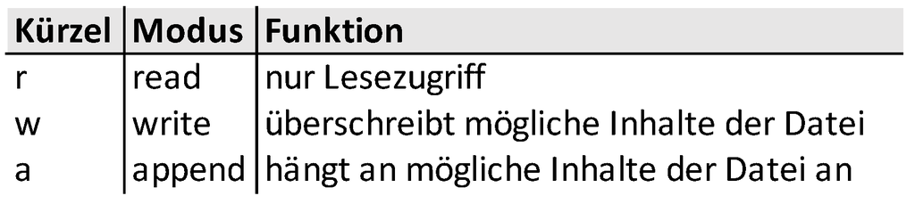

## Dateien schreiben

Inhalt in eine Datei schreiben:

```python
text = 'Was ich schon immer sagen wollte'

with open('Daten/my_file.txt', 'w') as output_file:
    output_file.write(text)
```

Inhalt über eine Schleife in eine Datei schreiben:

```python
with open('Daten/my_file.txt', 'w') as output:
    for item in einkaufsliste:
        output.write(item + '\n')
```

## Im nächsten Teil:

- Debugging: Wo ist der Fehler?
- Dictionaries
- Module einbinden und nutzen
  - os-Modul
  - NumPy